# Exploratory Data Analysis (EDA) and Dimensionality Reduction

## Principal Component Analysis (PCA)

PCA reduces dimensionality while preserving as much variance as possible. Therefore, I conduct PCA analysis to uncover latent patterns in the data and address multicollinearity among features.

```r
pca_result <- prcomp(numeric_admits, center = TRUE, scale. = TRUE)

# Summary of variance explained
summary(pca_result)
```

```
Importance of components:
                          PC1    PC2    PC3     PC4     PC5     PC6     PC7
Standard deviation     2.4613 1.7110 1.4287 1.27494 1.09896 1.04558 0.95518
Proportion of Variance 0.3188 0.1541 0.1074 0.08555 0.06356 0.05754 0.04802
Cumulative Proportion  0.3188 0.4729 0.5803 0.66590 0.72946 0.78700 0.83502
                           PC8     PC9    PC10    PC11   PC12    PC13   PC14
Standard deviation     0.92181 0.74409 0.73431 0.61307 0.5531 0.49574 0.3173
Proportion of Variance 0.04472 0.02914 0.02838 0.01978 0.0161 0.01293 0.0053
Cumulative Proportion  0.87974 0.90888 0.93726 0.95704 0.9731 0.98608 0.9914
                         PC15    PC16    PC17    PC18      PC19
Standard deviation     0.2923 0.21624 0.13247 0.11880 1.361e-15
Proportion of Variance 0.0045 0.00246 0.00092 0.00074 0.000e+00
Cumulative Proportion  0.9959 0.99833 0.99926 1.00000 1.000e+00
```

### PCA Scree Plot

The scree plot below visualizes how much variance each principal component explains. This helps identify the number of components worth retaining.

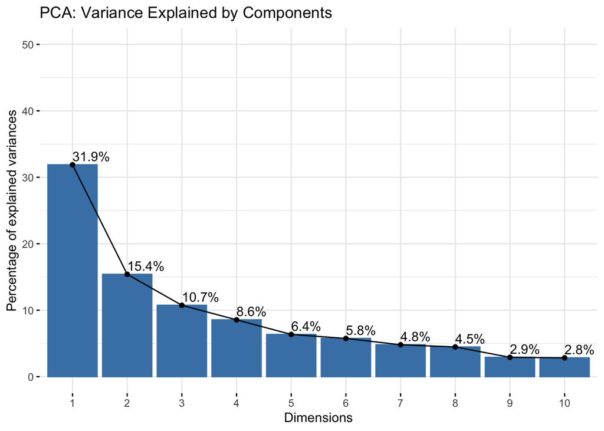

```r
fviz_eig(pca_result, addlabels = TRUE, ylim = c(0, 50),
         main = "PCA: Variance Explained by Components")
```

### PCA Biplot

To better understand which variables contribute the most to the principal components, I use a PCA variable contribution plot. This visualization highlights how strongly each original feature influences the principal components.

The color gradient emphasizes the level of contribution - with darker red tones indicating features that play a larger role in shaping the principal component axes. This helps identify which variables carry the most variance and may be most informative for modeling or further analysis.

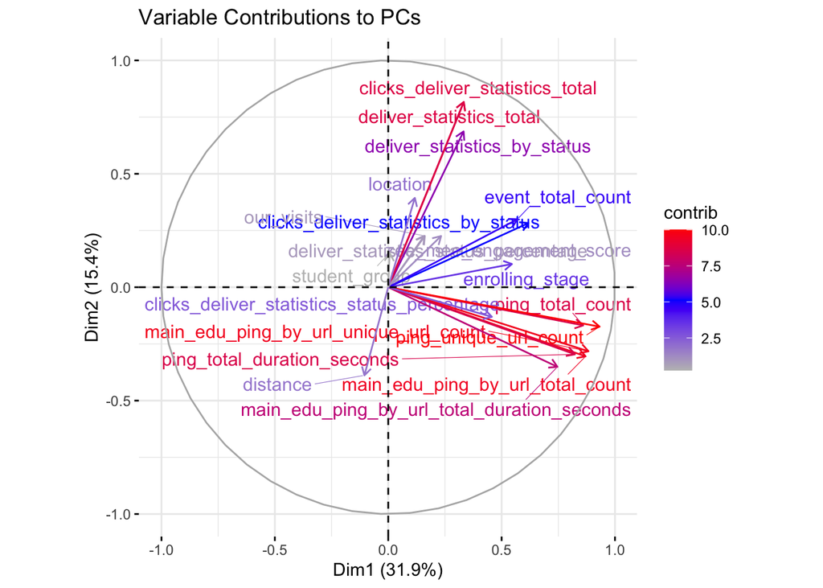

```r
fviz_pca_var(pca_result, col.var = "contrib",
             gradient.cols = c("gray", "blue", "red"),
             repel = TRUE, title = "Variable Contributions to PCs")
```

### Ranking Feature Importance by PCA Loadings

To quantitatively assess how much each variable contributes to the principal components, I extracted the PCA loadings from the `rotation` matrix. These loadings represent the weight or influence each original variable has on a given principal component.

By sorting the absolute values of the loadings for PC1, I can identify which features are most strongly associated with that component. This helps pinpoint the variables driving the structure captured by each principal component.

```r
pca_contrib <- as.data.frame(pca_result$rotation)
pca_contrib$variable <- rownames(pca_contrib)

pca_contrib %>%
  arrange(desc(abs(PC1))) %>%
  select(variable, PC1, PC2, PC3)
```

```
                                                                               variable
ping_unique_url_count                                             ping_unique_url_count
main_edu_ping_by_url_unique_url_count             main_edu_ping_by_url_unique_url_count
main_edu_ping_by_url_total_count                       main_edu_ping_by_url_total_count
ping_total_count                                                       ping_total_count
ping_total_duration_seconds                                 ping_total_duration_seconds
main_edu_ping_by_url_total_duration_seconds main_edu_ping_by_url_total_duration_seconds
clicks_deliver_statistics_by_status                 clicks_deliver_statistics_by_status
event_total_count                                                     event_total_count
enrolling_stage                                                         enrolling_stage
clicks_deliver_statistics_status_percentage clicks_deliver_statistics_status_percentage
clicks_deliver_statistics_total                         clicks_deliver_statistics_total
deliver_statistics_total                                       deliver_statistics_total
deliver_statistics_by_status                               deliver_statistics_by_status
zee_mee_engagement_score                                       zee_mee_engagement_score
deliver_statistics_status_percentage               deliver_statistics_status_percentage
our_visits                                                                   our_visits
location                                                                       location
distance                                                                       distance
student_group                                                             student_group
                                                     PC1         PC2
ping_unique_url_count                        0.378759252 -0.10164144
main_edu_ping_by_url_unique_url_count        0.358853076 -0.16503048
main_edu_ping_by_url_total_count             0.353679221 -0.17820516
ping_total_count                             0.349371017 -0.09834075
ping_total_duration_seconds                  0.334531369 -0.17292397
main_edu_ping_by_url_total_duration_seconds  0.303211623 -0.20521869
clicks_deliver_statistics_by_status          0.251174470  0.16531753
event_total_count                            0.231452981  0.17514821
enrolling_stage                              0.221673512  0.05978894
clicks_deliver_statistics_status_percentage  0.185813169 -0.07639614
clicks_deliver_statistics_total              0.135399788  0.47730272
deliver_statistics_total                     0.135399788  0.47730272
deliver_statistics_by_status                 0.135037563  0.40148363
zee_mee_engagement_score                     0.094768063  0.13185461
deliver_statistics_status_percentage         0.065533192  0.13188624
our_visits                                   0.064527271  0.13255728
location                                     0.047677826  0.23020024
distance                                    -0.042700006 -0.22712738
student_group                                0.002515981  0.08840685
                                                    PC3
ping_unique_url_count                        0.04723993
main_edu_ping_by_url_unique_url_count        0.11013818
main_edu_ping_by_url_total_count             0.14375863
ping_total_count                             0.06265625
ping_total_duration_seconds                  0.15037984
main_edu_ping_by_url_total_duration_seconds  0.19039791
clicks_deliver_statistics_by_status         -0.31723054
event_total_count                           -0.22659445
enrolling_stage                             -0.22693100
clicks_deliver_statistics_status_percentage -0.39965310
clicks_deliver_statistics_total              0.16094310
deliver_statistics_total                     0.16094310
deliver_statistics_by_status                -0.09541151
zee_mee_engagement_score                    -0.27837213
deliver_statistics_status_percentage        -0.24852145
our_visits                                  -0.05555586
location                                     0.38596565
distance                                    -0.37885747
student_group                               -0.20791350
```

### Interpretation of PCA

- The first few principal components capture a large portion of the variance, indicating that dimensionality reduction is feasible.
- Strongly correlated digital engagement features contribute heavily to the first principal component.
- Some variables show minimal influence across all components and may be candidates for removal.

```r
# Create correlation matrix
corr_matrix <- cor(numeric_admits)
high_corr_pairs <- which(abs(corr_matrix) > 0.7 & abs(corr_matrix) < 1, arr.ind = TRUE)

# Display top correlated pairs
correlated_vars <- unique(apply(high_corr_pairs, 1, function(i) paste(sort(colnames(corr_matrix)[i]), collapse = " vs ")))
correlated_vars
```

```
 [1] "main_edu_ping_by_url_total_count vs main_edu_ping_by_url_total_duration_seconds"
 [2] "main_edu_ping_by_url_total_duration_seconds vs main_edu_ping_by_url_unique_url_count"
 [3] "main_edu_ping_by_url_total_duration_seconds vs ping_total_duration_seconds"
 [4] "main_edu_ping_by_url_total_count vs main_edu_ping_by_url_unique_url_count"
 [5] "main_edu_ping_by_url_total_count vs ping_total_duration_seconds"
 [6] "main_edu_ping_by_url_total_count vs ping_total_count"
 [7] "main_edu_ping_by_url_total_count vs ping_unique_url_count"
 [8] "main_edu_ping_by_url_unique_url_count vs ping_total_duration_seconds"
 [9] "main_edu_ping_by_url_unique_url_count vs ping_total_count"
[10] "main_edu_ping_by_url_unique_url_count vs ping_unique_url_count"
[11] "ping_total_count vs ping_total_duration_seconds"
[12] "ping_total_duration_seconds vs ping_unique_url_count"
[13] "ping_total_count vs ping_unique_url_count"
[14] "deliver_statistics_by_status vs deliver_statistics_status_percentage"
[15] "clicks_deliver_statistics_by_status vs clicks_deliver_statistics_status_percentage"
```

```r
# Calculate contribution (loading squared) to each component
loadings <- pca_result$rotation[, 1:3]  # top 3 components
contrib_df <- as.data.frame(loadings^2)
contrib_df$variable <- rownames(loadings)
contrib_df$total_contrib <- rowSums(contrib_df[, 1:3])

# Sort by total contribution across PC1–PC3
low_contributors <- contrib_df %>%
  arrange(total_contrib) %>%
  dplyr::filter(total_contrib < quantile(total_contrib, 0.25))  # bottom 25%
low_contributors
```

```
                                              PC1         PC2         PC3
our_visits                           4.163769e-03 0.017571432 0.003086453
student_group                        6.330161e-06 0.007815771 0.043228025
deliver_statistics_status_percentage 4.294599e-03 0.017393980 0.061762911
zee_mee_engagement_score             8.980986e-03 0.017385639 0.077491043
enrolling_stage                      4.913915e-02 0.003574718 0.051497679
                                                                 variable
our_visits                                                     our_visits
student_group                                               student_group
deliver_statistics_status_percentage deliver_statistics_status_percentage
zee_mee_engagement_score                         zee_mee_engagement_score
enrolling_stage                                           enrolling_stage
                                     total_contrib
our_visits                              0.02482165
student_group                           0.05105013
deliver_statistics_status_percentage    0.08345149
zee_mee_engagement_score                0.10385767
enrolling_stage                         0.10421154
```

```r
reduced_admits <- admits %>%
  select(
    -"our_visits",
    -"student_group",
    -"zee_mee_engagement_score",
    -"ping_total_count",
    -"ping_unique_url_count",
    -"main_edu_ping_by_url_total_count",
    -"main_edu_ping_by_url_unique_url_count",
    -"main_edu_ping_by_url_total_duration_seconds",
    -"clicks_deliver_statistics_by_status",
    -"deliver_statistics_by_status",
    -"distance",
    -"deliver_statistics_total",
    -"x10",
    -"clicks_deliver_statistics_total"
  )

skim(reduced_admits)
```

Data summary

| Name | reduced_admits |
| --- | --- |
| Number of rows | 18606 |
| Number of columns | 9 |
| _______________________ |  |
| Column type frequency: |  |
| character | 3 |
| numeric | 6 |
| ________________________ |  |
| Group variables | None |

**Variable type: character**

| skim_variable | n_missing | complete_rate | min | max | empty | n_unique | whitespace |
| --- | --- | --- | --- | --- | --- | --- | --- |
| year | 0 | 1 | 4 | 4 | 0 | 7 | 0 |
| period | 0 | 1 | 13 | 17 | 0 | 8 | 0 |
| prospect_id | 0 | 1 | 36 | 36 | 0 | 18558 | 0 |

**Variable type: numeric**

| skim_variable | n_missing | complete_rate | mean | sd | p0 | p25 | p50 | p75 | p100 | hist |
| --- | --- | --- | --- | --- | --- | --- | --- | --- | --- | --- |
| enrolling_stage | 0 | 1 | 0.19 | 0.39 | 0 | 0.00 | 0.00 | 0.00 | 1 | ▇▁▁▁▂ |
| ping_total_duration_seconds | 0 | 1 | 4311.89 | 10917.51 | 0 | 270.00 | 1322.50 | 4262.00 | 371340 | ▇▁▁▁▁ |
| deliver_statistics_status_percentage | 0 | 1 | 50.02 | 23.82 | 0 | 31.31 | 51.06 | 68.97 | 100 | ▃▆▇▇▃ |
| clicks_deliver_statistics_status_percentage | 0 | 1 | 11.40 | 10.74 | 0 | 4.26 | 8.51 | 15.58 | 100 | ▇▁▁▁▁ |
| event_total_count | 0 | 1 | 0.70 | 1.06 | 0 | 0.00 | 0.00 | 1.00 | 11 | ▇▁▁▁▁ |
| location | 12 | 1 | 1.40 | 0.67 | 0 | 1.00 | 2.00 | 2.00 | 2 | ▂▁▆▁▇ |